# Risk Factor Analysis

## Outcome Variable

**Outcome Variable:** ever_stunted

## Predictor Variables

**Intervention Variable:** impfloor

**Adjustment Set:**

unadjusted

## Stratifying Variables

The analysis was stratified on these variable(s):

- agecat
- studyid
- country

## Data Summary

| agecat | studyid | country | impfloor | ever_stunted | n_cell | n |
| --- | --- | --- | --- | --- | --- | --- |
| 0-6 months | ki0047075b-MAL-ED | BANGLADESH | 0 | 0 | 17 | 242 |
| 0-6 months | ki0047075b-MAL-ED | BANGLADESH | 0 | 1 | 2 | 242 |
| 0-6 months | ki0047075b-MAL-ED | BANGLADESH | 1 | 0 | 186 | 242 |
| 0-6 months | ki0047075b-MAL-ED | BANGLADESH | 1 | 1 | 37 | 242 |
| 0-6 months | ki0047075b-MAL-ED | BRAZIL | 0 | 0 | 2 | 210 |
| 0-6 months | ki0047075b-MAL-ED | BRAZIL | 0 | 1 | 0 | 210 |
| 0-6 months | ki0047075b-MAL-ED | BRAZIL | 1 | 0 | 187 | 210 |
| 0-6 months | ki0047075b-MAL-ED | BRAZIL | 1 | 1 | 21 | 210 |
| 0-6 months | ki0047075b-MAL-ED | INDIA | 0 | 0 | 14 | 235 |
| 0-6 months | ki0047075b-MAL-ED | INDIA | 0 | 1 | 1 | 235 |
| 0-6 months | ki0047075b-MAL-ED | INDIA | 1 | 0 | 182 | 235 |
| 0-6 months | ki0047075b-MAL-ED | INDIA | 1 | 1 | 38 | 235 |
| 0-6 months | ki0047075b-MAL-ED | NEPAL | 0 | 0 | 117 | 229 |
| 0-6 months | ki0047075b-MAL-ED | NEPAL | 0 | 1 | 9 | 229 |
| 0-6 months | ki0047075b-MAL-ED | NEPAL | 1 | 0 | 86 | 229 |
| 0-6 months | ki0047075b-MAL-ED | NEPAL | 1 | 1 | 17 | 229 |
| 0-6 months | ki0047075b-MAL-ED | PERU | 0 | 0 | 190 | 272 |
| 0-6 months | ki0047075b-MAL-ED | PERU | 0 | 1 | 23 | 272 |
| 0-6 months | ki0047075b-MAL-ED | PERU | 1 | 0 | 48 | 272 |
| 0-6 months | ki0047075b-MAL-ED | PERU | 1 | 1 | 11 | 272 |
| 0-6 months | ki0047075b-MAL-ED | SOUTH AFRICA | 0 | 0 | 20 | 257 |
| 0-6 months | ki0047075b-MAL-ED | SOUTH AFRICA | 0 | 1 | 1 | 257 |
| 0-6 months | ki0047075b-MAL-ED | SOUTH AFRICA | 1 | 0 | 211 | 257 |
| 0-6 months | ki0047075b-MAL-ED | SOUTH AFRICA | 1 | 1 | 25 | 257 |
| 0-6 months | ki0047075b-MAL-ED | TANZANIA, UNITED REPUBLIC OF | 0 | 0 | 198 | 248 |
| 0-6 months | ki0047075b-MAL-ED | TANZANIA, UNITED REPUBLIC OF | 0 | 1 | 36 | 248 |
| 0-6 months | ki0047075b-MAL-ED | TANZANIA, UNITED REPUBLIC OF | 1 | 0 | 11 | 248 |
| 0-6 months | ki0047075b-MAL-ED | TANZANIA, UNITED REPUBLIC OF | 1 | 1 | 3 | 248 |
| 0-6 months | ki1000108-CMC-V-BCS-2002 | INDIA | 1 | 0 | 195 | 257 |
| 0-6 months | ki1000108-CMC-V-BCS-2002 | INDIA | 1 | 1 | 62 | 257 |

[output cut: 150 more lines]

The following strata were considered:

- agecat: 0-24 months, studyid: ki0047075b-MAL-ED, country: BANGLADESH
- agecat: 0-24 months, studyid: ki0047075b-MAL-ED, country: BRAZIL
- agecat: 0-24 months, studyid: ki0047075b-MAL-ED, country: INDIA
- agecat: 0-24 months, studyid: ki0047075b-MAL-ED, country: NEPAL
- agecat: 0-24 months, studyid: ki0047075b-MAL-ED, country: PERU
- agecat: 0-24 months, studyid: ki0047075b-MAL-ED, country: SOUTH AFRICA
- agecat: 0-24 months, studyid: ki0047075b-MAL-ED, country: TANZANIA, UNITED REPUBLIC OF
- agecat: 0-24 months, studyid: ki1000108-CMC-V-BCS-2002, country: INDIA
- agecat: 0-24 months, studyid: ki1000108-IRC, country: INDIA
- agecat: 0-24 months, studyid: ki1017093-NIH-Birth, country: BANGLADESH
- agecat: 0-24 months, studyid: ki1017093b-PROVIDE, country: BANGLADESH
- agecat: 0-24 months, studyid: ki1017093c-NIH-Crypto, country: BANGLADESH
- agecat: 0-24 months, studyid: ki1113344-GMS-Nepal, country: NEPAL
- agecat: 0-24 months, studyid: ki1114097-CONTENT, country: PERU
- agecat: 0-24 months, studyid: kiGH5241-JiVitA-3, country: BANGLADESH
- agecat: 0-24 months, studyid: kiGH5241-JiVitA-4, country: BANGLADESH
- agecat: 0-6 months, studyid: ki0047075b-MAL-ED, country: BANGLADESH
- agecat: 0-6 months, studyid: ki0047075b-MAL-ED, country: BRAZIL
- agecat: 0-6 months, studyid: ki0047075b-MAL-ED, country: INDIA
- agecat: 0-6 months, studyid: ki0047075b-MAL-ED, country: NEPAL
- agecat: 0-6 months, studyid: ki0047075b-MAL-ED, country: PERU
- agecat: 0-6 months, studyid: ki0047075b-MAL-ED, country: SOUTH AFRICA
- agecat: 0-6 months, studyid: ki0047075b-MAL-ED, country: TANZANIA, UNITED REPUBLIC OF
- agecat: 0-6 months, studyid: ki1000108-CMC-V-BCS-2002, country: INDIA
- agecat: 0-6 months, studyid: ki1000108-IRC, country: INDIA
- agecat: 0-6 months, studyid: ki1017093-NIH-Birth, country: BANGLADESH
- agecat: 0-6 months, studyid: ki1017093b-PROVIDE, country: BANGLADESH
- agecat: 0-6 months, studyid: ki1017093c-NIH-Crypto, country: BANGLADESH
- agecat: 0-6 months, studyid: ki1113344-GMS-Nepal, country: NEPAL
- agecat: 0-6 months, studyid: ki1114097-CONTENT, country: PERU
- agecat: 0-6 months, studyid: kiGH5241-JiVitA-3, country: BANGLADESH
- agecat: 0-6 months, studyid: kiGH5241-JiVitA-4, country: BANGLADESH
- agecat: 6-24 months, studyid: ki0047075b-MAL-ED, country: BANGLADESH
- agecat: 6-24 months, studyid: ki0047075b-MAL-ED, country: BRAZIL
- agecat: 6-24 months, studyid: ki0047075b-MAL-ED, country: INDIA
- agecat: 6-24 months, studyid: ki0047075b-MAL-ED, country: NEPAL
- agecat: 6-24 months, studyid: ki0047075b-MAL-ED, country: PERU
- agecat: 6-24 months, studyid: ki0047075b-MAL-ED, country: SOUTH AFRICA
- agecat: 6-24 months, studyid: ki0047075b-MAL-ED, country: TANZANIA, UNITED REPUBLIC OF
- agecat: 6-24 months, studyid: ki1000108-CMC-V-BCS-2002, country: INDIA
- agecat: 6-24 months, studyid: ki1000108-IRC, country: INDIA
- agecat: 6-24 months, studyid: ki1017093-NIH-Birth, country: BANGLADESH
- agecat: 6-24 months, studyid: ki1017093b-PROVIDE, country: BANGLADESH
- agecat: 6-24 months, studyid: ki1017093c-NIH-Crypto, country: BANGLADESH
- agecat: 6-24 months, studyid: ki1113344-GMS-Nepal, country: NEPAL
- agecat: 6-24 months, studyid: ki1114097-CONTENT, country: PERU
- agecat: 6-24 months, studyid: kiGH5241-JiVitA-3, country: BANGLADESH
- agecat: 6-24 months, studyid: kiGH5241-JiVitA-4, country: BANGLADESH

### Dropped Strata

Some strata were dropped due to rare outcomes:

- agecat: 0-6 months, studyid: ki0047075b-MAL-ED, country: BANGLADESH
- agecat: 0-6 months, studyid: ki0047075b-MAL-ED, country: BRAZIL
- agecat: 0-6 months, studyid: ki0047075b-MAL-ED, country: INDIA
- agecat: 0-6 months, studyid: ki0047075b-MAL-ED, country: SOUTH AFRICA
- agecat: 0-6 months, studyid: ki0047075b-MAL-ED, country: TANZANIA, UNITED REPUBLIC OF
- agecat: 0-6 months, studyid: ki1114097-CONTENT, country: PERU
- agecat: 6-24 months, studyid: ki0047075b-MAL-ED, country: BRAZIL
- agecat: 6-24 months, studyid: ki0047075b-MAL-ED, country: INDIA
- agecat: 6-24 months, studyid: ki0047075b-MAL-ED, country: TANZANIA, UNITED REPUBLIC OF
- agecat: 6-24 months, studyid: ki1114097-CONTENT, country: PERU
- agecat: 0-24 months, studyid: ki0047075b-MAL-ED, country: BRAZIL
- agecat: 0-24 months, studyid: ki1114097-CONTENT, country: PERU

## Methods Detail

We’re interested in the causal parameters $E[Y_a]$ for all values of $a \in \mathcal{A}$. These parameters represent the mean outcome if, possibly contrary to fact, we intervened to set all units to have $A=a$. Under the randomization and positivity assumptions, these are identified by the statistical parameters $\psi_a=E_W[E_{Y|A,W}(Y|A=a,W)]$. In addition, we’re interested in the mean of $Y$, $E[Y]$ under no intervention (the observed mean). We will estimate these parameters by using SuperLearner to fit the relevant likelihood factors – $E_{Y|A,W}(Y|A=a,W)$ and $p(A=a|W)$, and then updating our likelihood fit using a joint TMLE.

For unadjusted analyses ($W=\{\}$), initial likelihoods were estimated using Lrnr_glm to estimate the simple $E(Y|A)$ and Lrnr_mean to estimate $p(A)$. For adjusted analyses, a small library containing Lrnr_glmnet, Lrnr_xgboost, and Lrnr_mean was used.

Having estimated these parameters, we will then use the delta method to estimate relative risks and attributable risks relative to a prespecified baseline level of $A$.

```
##         ever_stunted
## impfloor   0   1
##        0   0   0
##        1  51 210
##         ever_stunted
## impfloor   0   1
##        0   0   0
##        1 169 137
##         ever_stunted
## impfloor   0   1
##        0   0   0
##        1 195  62
##         ever_stunted
## impfloor   0   1
##        0   0   0
##        1 270  36
##         ever_stunted
## impfloor   0   1
##        0   0   0
##        1  68 128
##         ever_stunted
## impfloor   0   1
##        0   0   0
##        1 199  62
```

# Results Detail

## Results Plots

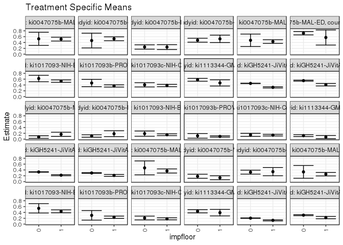

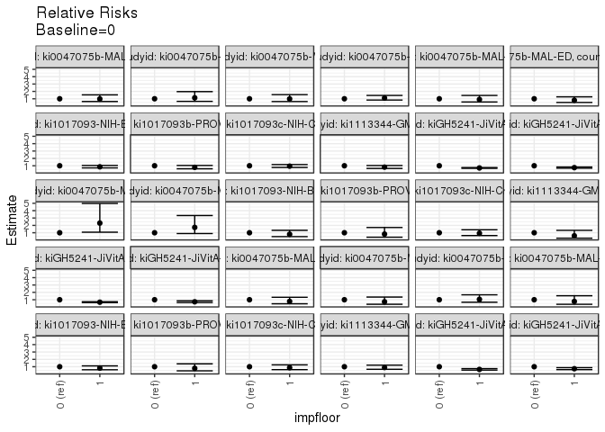

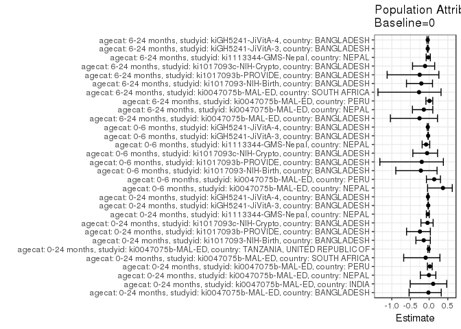

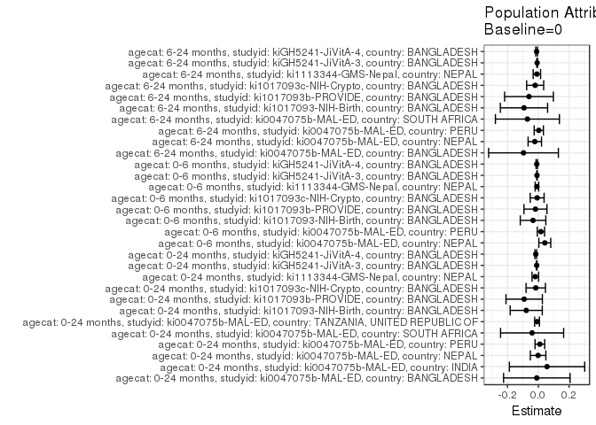

## Results Table

### Parameter: TSM

| agecat | studyid | country | intervention_level | baseline_level | estimate | ci_lower | ci_upper |
| --- | --- | --- | --- | --- | --- | --- | --- |
| 0-24 months | ki0047075b-MAL-ED | BANGLADESH | 0 | NA | 0.5263158 | 0.3013388 | 0.7512928 |
| 0-24 months | ki0047075b-MAL-ED | BANGLADESH | 1 | NA | 0.5156951 | 0.4499670 | 0.5814231 |
| 0-24 months | ki0047075b-MAL-ED | INDIA | 0 | NA | 0.4666667 | 0.2136604 | 0.7196729 |
| 0-24 months | ki0047075b-MAL-ED | INDIA | 1 | NA | 0.5272727 | 0.4611599 | 0.5933856 |
| 0-24 months | ki0047075b-MAL-ED | NEPAL | 0 | NA | 0.2460317 | 0.1706640 | 0.3213994 |
| 0-24 months | ki0047075b-MAL-ED | NEPAL | 1 | NA | 0.2427184 | 0.1597410 | 0.3256959 |
| 0-24 months | ki0047075b-MAL-ED | PERU | 0 | NA | 0.4788732 | 0.4116623 | 0.5460842 |
| 0-24 months | ki0047075b-MAL-ED | PERU | 1 | NA | 0.5254237 | 0.3977711 | 0.6530764 |
| 0-24 months | ki0047075b-MAL-ED | SOUTH AFRICA | 0 | NA | 0.4761905 | 0.2621667 | 0.6902143 |
| 0-24 months | ki0047075b-MAL-ED | SOUTH AFRICA | 1 | NA | 0.4322034 | 0.3688778 | 0.4955290 |
| 0-24 months | ki0047075b-MAL-ED | TANZANIA, UNITED REPUBLIC OF | 0 | NA | 0.7179487 | 0.6601753 | 0.7757222 |
| 0-24 months | ki0047075b-MAL-ED | TANZANIA, UNITED REPUBLIC OF | 1 | NA | 0.5714286 | 0.3116795 | 0.8311777 |
| 0-24 months | ki1017093-NIH-Birth | BANGLADESH | 0 | NA | 0.6216216 | 0.5110342 | 0.7322090 |
| 0-24 months | ki1017093-NIH-Birth | BANGLADESH | 1 | NA | 0.5326087 | 0.4909534 | 0.5742640 |
| 0-24 months | ki1017093b-PROVIDE | BANGLADESH | 0 | NA | 0.4677419 | 0.3434546 | 0.5920293 |
| 0-24 months | ki1017093b-PROVIDE | BANGLADESH | 1 | NA | 0.3667712 | 0.3293492 | 0.4041931 |
| 0-24 months | ki1017093c-NIH-Crypto | BANGLADESH | 0 | NA | 0.4044944 | 0.3323464 | 0.4766423 |
| 0-24 months | ki1017093c-NIH-Crypto | BANGLADESH | 1 | NA | 0.3827586 | 0.3431754 | 0.4223418 |
| 0-24 months | ki1113344-GMS-Nepal | NEPAL | 0 | NA | 0.5784062 | 0.5292820 | 0.6275304 |
| 0-24 months | ki1113344-GMS-Nepal | NEPAL | 1 | NA | 0.4705882 | 0.3643662 | 0.5768103 |
| 0-24 months | kiGH5241-JiVitA-3 | BANGLADESH | 0 | NA | 0.4544511 | 0.4467644 | 0.4621377 |
| 0-24 months | kiGH5241-JiVitA-3 | BANGLADESH | 1 | NA | 0.3182887 | 0.2963211 | 0.3402562 |
| 0-24 months | kiGH5241-JiVitA-4 | BANGLADESH | 0 | NA | 0.5488801 | 0.5319742 | 0.5657859 |
| 0-24 months | kiGH5241-JiVitA-4 | BANGLADESH | 1 | NA | 0.4089506 | 0.3659535 | 0.4519478 |
| 0-6 months | ki0047075b-MAL-ED | NEPAL | 0 | NA | 0.0714286 | 0.0263618 | 0.1164954 |
| 0-6 months | ki0047075b-MAL-ED | NEPAL | 1 | NA | 0.1650485 | 0.0932003 | 0.2368968 |
| 0-6 months | ki0047075b-MAL-ED | PERU | 0 | NA | 0.1079812 | 0.0662252 | 0.1497373 |
| 0-6 months | ki0047075b-MAL-ED | PERU | 1 | NA | 0.1864407 | 0.0868802 | 0.2860011 |
| 0-6 months | ki1017093-NIH-Birth | BANGLADESH | 0 | NA | 0.1891892 | 0.0998818 | 0.2784966 |
| 0-6 months | ki1017093-NIH-Birth | BANGLADESH | 1 | NA | 0.1503623 | 0.1205214 | 0.1802032 |
| 0-6 months | ki1017093b-PROVIDE | BANGLADESH | 0 | NA | 0.1129032 | 0.0340714 | 0.1917350 |
| 0-6 months | ki1017093b-PROVIDE | BANGLADESH | 1 | NA | 0.0924765 | 0.0699811 | 0.1149718 |
| 0-6 months | ki1017093c-NIH-Crypto | BANGLADESH | 0 | NA | 0.1460674 | 0.0941500 | 0.1979848 |
| 0-6 months | ki1017093c-NIH-Crypto | BANGLADESH | 1 | NA | 0.1362069 | 0.1082734 | 0.1641404 |
| 0-6 months | ki1113344-GMS-Nepal | NEPAL | 0 | NA | 0.1208226 | 0.0884003 | 0.1532450 |
| 0-6 months | ki1113344-GMS-Nepal | NEPAL | 1 | NA | 0.0705882 | 0.0160793 | 0.1250971 |
| 0-6 months | kiGH5241-JiVitA-3 | BANGLADESH | 0 | NA | 0.3306916 | 0.3237024 | 0.3376808 |
| 0-6 months | kiGH5241-JiVitA-3 | BANGLADESH | 1 | NA | 0.2197543 | 0.2004373 | 0.2390713 |
| 0-6 months | kiGH5241-JiVitA-4 | BANGLADESH | 0 | NA | 0.2965763 | 0.2818172 | 0.3113353 |
| 0-6 months | kiGH5241-JiVitA-4 | BANGLADESH | 1 | NA | 0.2132472 | 0.1792183 | 0.2472761 |
| 6-24 months | ki0047075b-MAL-ED | BANGLADESH | 0 | NA | 0.4705882 | 0.2327085 | 0.7084679 |
| 6-24 months | ki0047075b-MAL-ED | BANGLADESH | 1 | NA | 0.3651685 | 0.2942548 | 0.4360823 |
| 6-24 months | ki0047075b-MAL-ED | NEPAL | 0 | NA | 0.1833333 | 0.1139430 | 0.2527237 |
| 6-24 months | ki0047075b-MAL-ED | NEPAL | 1 | NA | 0.1326531 | 0.0653417 | 0.1999644 |
| 6-24 months | ki0047075b-MAL-ED | PERU | 0 | NA | 0.3243243 | 0.2567205 | 0.3919282 |
| 6-24 months | ki0047075b-MAL-ED | PERU | 1 | NA | 0.3409091 | 0.2005424 | 0.4812758 |
| 6-24 months | ki0047075b-MAL-ED | SOUTH AFRICA | 0 | NA | 0.3333333 | 0.1150652 | 0.5516015 |
| 6-24 months | ki0047075b-MAL-ED | SOUTH AFRICA | 1 | NA | 0.2561576 | 0.1959739 | 0.3163413 |
| 6-24 months | ki1017093-NIH-Birth | BANGLADESH | 0 | NA | 0.5405405 | 0.3797705 | 0.7013106 |
| 6-24 months | ki1017093-NIH-Birth | BANGLADESH | 1 | NA | 0.4383202 | 0.3884380 | 0.4882024 |
| 6-24 months | ki1017093b-PROVIDE | BANGLADESH | 0 | NA | 0.3000000 | 0.1358524 | 0.4641476 |
| 6-24 months | ki1017093b-PROVIDE | BANGLADESH | 1 | NA | 0.2355460 | 0.1970212 | 0.2740709 |
| 6-24 months | ki1017093c-NIH-Crypto | BANGLADESH | 0 | NA | 0.2091503 | 0.1446549 | 0.2736458 |
| 6-24 months | ki1017093c-NIH-Crypto | BANGLADESH | 1 | NA | 0.1820128 | 0.1469890 | 0.2170367 |
| 6-24 months | ki1113344-GMS-Nepal | NEPAL | 0 | NA | 0.4401294 | 0.3847089 | 0.4955500 |
| 6-24 months | ki1113344-GMS-Nepal | NEPAL | 1 | NA | 0.3918919 | 0.2805205 | 0.5032632 |
| 6-24 months | kiGH5241-JiVitA-3 | BANGLADESH | 0 | NA | 0.2041329 | 0.1955276 | 0.2127381 |
| 6-24 months | kiGH5241-JiVitA-3 | BANGLADESH | 1 | NA | 0.1293495 | 0.1100173 | 0.1486816 |
| 6-24 months | kiGH5241-JiVitA-4 | BANGLADESH | 0 | NA | 0.3063739 | 0.2887280 | 0.3240198 |
| 6-24 months | kiGH5241-JiVitA-4 | BANGLADESH | 1 | NA | 0.2224168 | 0.1832700 | 0.2615636 |

### Parameter: E(Y)

| agecat | studyid | country | intervention_level | baseline_level | estimate | ci_lower | ci_upper |
| --- | --- | --- | --- | --- | --- | --- | --- |
| 0-24 months | ki0047075b-MAL-ED | BANGLADESH | NA | NA | 0.5165289 | 0.4534372 | 0.5796206 |
| 0-24 months | ki0047075b-MAL-ED | INDIA | NA | NA | 0.5234043 | 0.4594110 | 0.5873975 |
| 0-24 months | ki0047075b-MAL-ED | NEPAL | NA | NA | 0.2445415 | 0.1887507 | 0.3003322 |
| 0-24 months | ki0047075b-MAL-ED | PERU | NA | NA | 0.4889706 | 0.4294554 | 0.5484858 |
| 0-24 months | ki0047075b-MAL-ED | SOUTH AFRICA | NA | NA | 0.4357977 | 0.3750558 | 0.4965395 |
| 0-24 months | ki0047075b-MAL-ED | TANZANIA, UNITED REPUBLIC OF | NA | NA | 0.7096774 | 0.6530704 | 0.7662845 |
| 0-24 months | ki1017093-NIH-Birth | BANGLADESH | NA | NA | 0.5431310 | 0.5040778 | 0.5821842 |
| 0-24 months | ki1017093b-PROVIDE | BANGLADESH | NA | NA | 0.3757143 | 0.3398113 | 0.4116172 |
| 0-24 months | ki1017093c-NIH-Crypto | BANGLADESH | NA | NA | 0.3878628 | 0.3531521 | 0.4225735 |
| 0-24 months | ki1113344-GMS-Nepal | NEPAL | NA | NA | 0.5590717 | 0.5143277 | 0.6038158 |
| 0-24 months | kiGH5241-JiVitA-3 | BANGLADESH | NA | NA | 0.4437900 | 0.4362765 | 0.4513035 |
| 0-24 months | kiGH5241-JiVitA-4 | BANGLADESH | NA | NA | 0.5321659 | 0.5159814 | 0.5483504 |
| 0-6 months | ki0047075b-MAL-ED | NEPAL | NA | NA | 0.1135371 | 0.0723577 | 0.1547165 |
| 0-6 months | ki0047075b-MAL-ED | PERU | NA | NA | 0.1250000 | 0.0856248 | 0.1643752 |
| 0-6 months | ki1017093-NIH-Birth | BANGLADESH | NA | NA | 0.1549521 | 0.1265829 | 0.1833213 |
| 0-6 months | ki1017093b-PROVIDE | BANGLADESH | NA | NA | 0.0942857 | 0.0726222 | 0.1159492 |
| 0-6 months | ki1017093c-NIH-Crypto | BANGLADESH | NA | NA | 0.1385224 | 0.1139141 | 0.1631308 |
| 0-6 months | ki1113344-GMS-Nepal | NEPAL | NA | NA | 0.1118143 | 0.0834144 | 0.1402143 |
| 0-6 months | kiGH5241-JiVitA-3 | BANGLADESH | NA | NA | 0.3220295 | 0.3152463 | 0.3288127 |
| 0-6 months | kiGH5241-JiVitA-4 | BANGLADESH | NA | NA | 0.2864960 | 0.2726657 | 0.3003263 |
| 6-24 months | ki0047075b-MAL-ED | BANGLADESH | NA | NA | 0.3743590 | 0.3062579 | 0.4424600 |
| 6-24 months | ki0047075b-MAL-ED | NEPAL | NA | NA | 0.1605505 | 0.1117053 | 0.2093956 |
| 6-24 months | ki0047075b-MAL-ED | PERU | NA | NA | 0.3275109 | 0.2665942 | 0.3884276 |
| 6-24 months | ki0047075b-MAL-ED | SOUTH AFRICA | NA | NA | 0.2624434 | 0.2043065 | 0.3205804 |
| 6-24 months | ki1017093-NIH-Birth | BANGLADESH | NA | NA | 0.4473684 | 0.3996451 | 0.4950917 |
| 6-24 months | ki1017093b-PROVIDE | BANGLADESH | NA | NA | 0.2394366 | 0.2018814 | 0.2769918 |
| 6-24 months | ki1017093c-NIH-Crypto | BANGLADESH | NA | NA | 0.1887097 | 0.1578857 | 0.2195336 |
| 6-24 months | ki1113344-GMS-Nepal | NEPAL | NA | NA | 0.4308094 | 0.3811516 | 0.4804672 |
| 6-24 months | kiGH5241-JiVitA-3 | BANGLADESH | NA | NA | 0.1966855 | 0.1886595 | 0.2047115 |
| 6-24 months | kiGH5241-JiVitA-4 | BANGLADESH | NA | NA | 0.2952381 | 0.2788899 | 0.3115863 |

### Parameter: RR

| agecat | studyid | country | intervention_level | baseline_level | estimate | ci_lower | ci_upper |
| --- | --- | --- | --- | --- | --- | --- | --- |
| 0-24 months | ki0047075b-MAL-ED | BANGLADESH | 0 | 0 | 1.0000000 | 1.0000000 | 1.0000000 |
| 0-24 months | ki0047075b-MAL-ED | BANGLADESH | 1 | 0 | 0.9798206 | 0.6272317 | 1.5306121 |
| 0-24 months | ki0047075b-MAL-ED | INDIA | 0 | 0 | 1.0000000 | 1.0000000 | 1.0000000 |
| 0-24 months | ki0047075b-MAL-ED | INDIA | 1 | 0 | 1.1298701 | 0.6476765 | 1.9710558 |
| 0-24 months | ki0047075b-MAL-ED | NEPAL | 0 | 0 | 1.0000000 | 1.0000000 | 1.0000000 |
| 0-24 months | ki0047075b-MAL-ED | NEPAL | 1 | 0 | 0.9865330 | 0.6233835 | 1.5612338 |
| 0-24 months | ki0047075b-MAL-ED | PERU | 0 | 0 | 1.0000000 | 1.0000000 | 1.0000000 |
| 0-24 months | ki0047075b-MAL-ED | PERU | 1 | 0 | 1.0972084 | 0.8287726 | 1.4525893 |
| 0-24 months | ki0047075b-MAL-ED | SOUTH AFRICA | 0 | 0 | 1.0000000 | 1.0000000 | 1.0000000 |
| 0-24 months | ki0047075b-MAL-ED | SOUTH AFRICA | 1 | 0 | 0.9076271 | 0.5657230 | 1.4561667 |
| 0-24 months | ki0047075b-MAL-ED | TANZANIA, UNITED REPUBLIC OF | 0 | 0 | 1.0000000 | 1.0000000 | 1.0000000 |
| 0-24 months | ki0047075b-MAL-ED | TANZANIA, UNITED REPUBLIC OF | 1 | 0 | 0.7959184 | 0.5016326 | 1.2628487 |
| 0-24 months | ki1017093-NIH-Birth | BANGLADESH | 0 | 0 | 1.0000000 | 1.0000000 | 1.0000000 |
| 0-24 months | ki1017093-NIH-Birth | BANGLADESH | 1 | 0 | 0.8568053 | 0.7054788 | 1.0405917 |
| 0-24 months | ki1017093b-PROVIDE | BANGLADESH | 0 | 0 | 1.0000000 | 1.0000000 | 1.0000000 |
| 0-24 months | ki1017093b-PROVIDE | BANGLADESH | 1 | 0 | 0.7841314 | 0.5898942 | 1.0423261 |
| 0-24 months | ki1017093c-NIH-Crypto | BANGLADESH | 0 | 0 | 1.0000000 | 1.0000000 | 1.0000000 |
| 0-24 months | ki1017093c-NIH-Crypto | BANGLADESH | 1 | 0 | 0.9462644 | 0.7699647 | 1.1629316 |
| 0-24 months | ki1113344-GMS-Nepal | NEPAL | 0 | 0 | 1.0000000 | 1.0000000 | 1.0000000 |
| 0-24 months | ki1113344-GMS-Nepal | NEPAL | 1 | 0 | 0.8135948 | 0.6392473 | 1.0354936 |
| 0-24 months | kiGH5241-JiVitA-3 | BANGLADESH | 0 | 0 | 1.0000000 | 1.0000000 | 1.0000000 |
| 0-24 months | kiGH5241-JiVitA-3 | BANGLADESH | 1 | 0 | 0.7003805 | 0.6528057 | 0.7514225 |
| 0-24 months | kiGH5241-JiVitA-4 | BANGLADESH | 0 | 0 | 1.0000000 | 1.0000000 | 1.0000000 |
| 0-24 months | kiGH5241-JiVitA-4 | BANGLADESH | 1 | 0 | 0.7450637 | 0.6690577 | 0.8297042 |
| 0-6 months | ki0047075b-MAL-ED | NEPAL | 0 | 0 | 1.0000000 | 1.0000000 | 1.0000000 |
| 0-6 months | ki0047075b-MAL-ED | NEPAL | 1 | 0 | 2.3106796 | 1.0735860 | 4.9732766 |
| 0-6 months | ki0047075b-MAL-ED | PERU | 0 | 0 | 1.0000000 | 1.0000000 | 1.0000000 |
| 0-6 months | ki0047075b-MAL-ED | PERU | 1 | 0 | 1.7266028 | 0.8930079 | 3.3383325 |
| 0-6 months | ki1017093-NIH-Birth | BANGLADESH | 0 | 0 | 1.0000000 | 1.0000000 | 1.0000000 |
| 0-6 months | ki1017093-NIH-Birth | BANGLADESH | 1 | 0 | 0.7947723 | 0.4762680 | 1.3262762 |
| 0-6 months | ki1017093b-PROVIDE | BANGLADESH | 0 | 0 | 1.0000000 | 1.0000000 | 1.0000000 |
| 0-6 months | ki1017093b-PROVIDE | BANGLADESH | 1 | 0 | 0.8190775 | 0.3910337 | 1.7156781 |
| 0-6 months | ki1017093c-NIH-Crypto | BANGLADESH | 0 | 0 | 1.0000000 | 1.0000000 | 1.0000000 |
| 0-6 months | ki1017093c-NIH-Crypto | BANGLADESH | 1 | 0 | 0.9324934 | 0.6186291 | 1.4055982 |
| 0-6 months | ki1113344-GMS-Nepal | NEPAL | 0 | 0 | 1.0000000 | 1.0000000 | 1.0000000 |
| 0-6 months | ki1113344-GMS-Nepal | NEPAL | 1 | 0 | 0.5842303 | 0.2579558 | 1.3231917 |
| 0-6 months | kiGH5241-JiVitA-3 | BANGLADESH | 0 | 0 | 1.0000000 | 1.0000000 | 1.0000000 |
| 0-6 months | kiGH5241-JiVitA-3 | BANGLADESH | 1 | 0 | 0.6645292 | 0.6075463 | 0.7268567 |
| 0-6 months | kiGH5241-JiVitA-4 | BANGLADESH | 0 | 0 | 1.0000000 | 1.0000000 | 1.0000000 |
| 0-6 months | kiGH5241-JiVitA-4 | BANGLADESH | 1 | 0 | 0.7190298 | 0.6093204 | 0.8484926 |
| 6-24 months | ki0047075b-MAL-ED | BANGLADESH | 0 | 0 | 1.0000000 | 1.0000000 | 1.0000000 |
| 6-24 months | ki0047075b-MAL-ED | BANGLADESH | 1 | 0 | 0.7759831 | 0.4515193 | 1.3336083 |
| 6-24 months | ki0047075b-MAL-ED | NEPAL | 0 | 0 | 1.0000000 | 1.0000000 | 1.0000000 |
| 6-24 months | ki0047075b-MAL-ED | NEPAL | 1 | 0 | 0.7235622 | 0.3841946 | 1.3627005 |
| 6-24 months | ki0047075b-MAL-ED | PERU | 0 | 0 | 1.0000000 | 1.0000000 | 1.0000000 |
| 6-24 months | ki0047075b-MAL-ED | PERU | 1 | 0 | 1.0511364 | 0.6625714 | 1.6675752 |
| 6-24 months | ki0047075b-MAL-ED | SOUTH AFRICA | 0 | 0 | 1.0000000 | 1.0000000 | 1.0000000 |
| 6-24 months | ki0047075b-MAL-ED | SOUTH AFRICA | 1 | 0 | 0.7684729 | 0.3832648 | 1.5408422 |
| 6-24 months | ki1017093-NIH-Birth | BANGLADESH | 0 | 0 | 1.0000000 | 1.0000000 | 1.0000000 |
| 6-24 months | ki1017093-NIH-Birth | BANGLADESH | 1 | 0 | 0.8108924 | 0.5897402 | 1.1149766 |
| 6-24 months | ki1017093b-PROVIDE | BANGLADESH | 0 | 0 | 1.0000000 | 1.0000000 | 1.0000000 |
| 6-24 months | ki1017093b-PROVIDE | BANGLADESH | 1 | 0 | 0.7851535 | 0.4435448 | 1.3898618 |
| 6-24 months | ki1017093c-NIH-Crypto | BANGLADESH | 0 | 0 | 1.0000000 | 1.0000000 | 1.0000000 |
| 6-24 months | ki1017093c-NIH-Crypto | BANGLADESH | 1 | 0 | 0.8702489 | 0.6050419 | 1.2517038 |
| 6-24 months | ki1113344-GMS-Nepal | NEPAL | 0 | 0 | 1.0000000 | 1.0000000 | 1.0000000 |
| 6-24 months | ki1113344-GMS-Nepal | NEPAL | 1 | 0 | 0.8904014 | 0.6525166 | 1.2150107 |
| 6-24 months | kiGH5241-JiVitA-3 | BANGLADESH | 0 | 0 | 1.0000000 | 1.0000000 | 1.0000000 |
| 6-24 months | kiGH5241-JiVitA-3 | BANGLADESH | 1 | 0 | 0.6336534 | 0.5422560 | 0.7404558 |
| 6-24 months | kiGH5241-JiVitA-4 | BANGLADESH | 0 | 0 | 1.0000000 | 1.0000000 | 1.0000000 |
| 6-24 months | kiGH5241-JiVitA-4 | BANGLADESH | 1 | 0 | 0.7259654 | 0.6039628 | 0.8726128 |

### Parameter: PAR

| agecat | studyid | country | intervention_level | baseline_level | estimate | ci_lower | ci_upper |
| --- | --- | --- | --- | --- | --- | --- | --- |
| 0-24 months | ki0047075b-MAL-ED | BANGLADESH | 0 | NA | -0.0097869 | -0.2257671 | 0.2061934 |
| 0-24 months | ki0047075b-MAL-ED | INDIA | 0 | NA | 0.0567376 | -0.1880797 | 0.3015549 |
| 0-24 months | ki0047075b-MAL-ED | NEPAL | 0 | NA | -0.0014903 | -0.0519095 | 0.0489290 |
| 0-24 months | ki0047075b-MAL-ED | PERU | 0 | NA | 0.0100973 | -0.0212788 | 0.0414735 |
| 0-24 months | ki0047075b-MAL-ED | SOUTH AFRICA | 0 | NA | -0.0403928 | -0.2453560 | 0.1645704 |
| 0-24 months | ki0047075b-MAL-ED | TANZANIA, UNITED REPUBLIC OF | 0 | NA | -0.0082713 | -0.0238736 | 0.0073310 |
| 0-24 months | ki1017093-NIH-Birth | BANGLADESH | 0 | NA | -0.0784906 | -0.1827182 | 0.0257369 |
| 0-24 months | ki1017093b-PROVIDE | BANGLADESH | 0 | NA | -0.0920276 | -0.2103492 | 0.0262939 |
| 0-24 months | ki1017093c-NIH-Crypto | BANGLADESH | 0 | NA | -0.0166316 | -0.0796033 | 0.0463402 |
| 0-24 months | ki1113344-GMS-Nepal | NEPAL | 0 | NA | -0.0193344 | -0.0406495 | 0.0019806 |
| 0-24 months | kiGH5241-JiVitA-3 | BANGLADESH | 0 | NA | -0.0106610 | -0.0125200 | -0.0088021 |
| 0-24 months | kiGH5241-JiVitA-4 | BANGLADESH | 0 | NA | -0.0167142 | -0.0223286 | -0.0110997 |
| 0-6 months | ki0047075b-MAL-ED | NEPAL | 0 | NA | 0.0421085 | 0.0034853 | 0.0807318 |
| 0-6 months | ki0047075b-MAL-ED | PERU | 0 | NA | 0.0170188 | -0.0067139 | 0.0407514 |
| 0-6 months | ki1017093-NIH-Birth | BANGLADESH | 0 | NA | -0.0342371 | -0.1172730 | 0.0487988 |
| 0-6 months | ki1017093b-PROVIDE | BANGLADESH | 0 | NA | -0.0186175 | -0.0933364 | 0.0561014 |
| 0-6 months | ki1017093c-NIH-Crypto | BANGLADESH | 0 | NA | -0.0075450 | -0.0526567 | 0.0375667 |
| 0-6 months | ki1113344-GMS-Nepal | NEPAL | 0 | NA | -0.0090083 | -0.0205134 | 0.0024968 |
| 0-6 months | kiGH5241-JiVitA-3 | BANGLADESH | 0 | NA | -0.0086621 | -0.0103151 | -0.0070092 |
| 0-6 months | kiGH5241-JiVitA-4 | BANGLADESH | 0 | NA | -0.0100803 | -0.0146299 | -0.0055306 |
| 6-24 months | ki0047075b-MAL-ED | BANGLADESH | 0 | NA | -0.0962293 | -0.3228525 | 0.1303940 |
| 6-24 months | ki0047075b-MAL-ED | NEPAL | 0 | NA | -0.0227829 | -0.0663710 | 0.0208053 |
| 6-24 months | ki0047075b-MAL-ED | PERU | 0 | NA | 0.0031866 | -0.0267604 | 0.0331336 |
| 6-24 months | ki0047075b-MAL-ED | SOUTH AFRICA | 0 | NA | -0.0708899 | -0.2788812 | 0.1371014 |
| 6-24 months | ki1017093-NIH-Birth | BANGLADESH | 0 | NA | -0.0931721 | -0.2466281 | 0.0602838 |
| 6-24 months | ki1017093b-PROVIDE | BANGLADESH | 0 | NA | -0.0605634 | -0.2189994 | 0.0978726 |
| 6-24 months | ki1017093c-NIH-Crypto | BANGLADESH | 0 | NA | -0.0204406 | -0.0757288 | 0.0348475 |
| 6-24 months | ki1113344-GMS-Nepal | NEPAL | 0 | NA | -0.0093201 | -0.0334310 | 0.0147909 |
| 6-24 months | kiGH5241-JiVitA-3 | BANGLADESH | 0 | NA | -0.0074474 | -0.0095959 | -0.0052988 |
| 6-24 months | kiGH5241-JiVitA-4 | BANGLADESH | 0 | NA | -0.0111358 | -0.0167556 | -0.0055160 |

### Parameter: PAF

| agecat | studyid | country | intervention_level | baseline_level | estimate | ci_lower | ci_upper |
| --- | --- | --- | --- | --- | --- | --- | --- |
| 0-24 months | ki0047075b-MAL-ED | BANGLADESH | 0 | NA | -0.0189474 | -0.5359359 | 0.3240254 |
| 0-24 months | ki0047075b-MAL-ED | INDIA | 0 | NA | 0.1084011 | -0.5069254 | 0.4724698 |
| 0-24 months | ki0047075b-MAL-ED | NEPAL | 0 | NA | -0.0060941 | -0.2349170 | 0.1803293 |
| 0-24 months | ki0047075b-MAL-ED | PERU | 0 | NA | 0.0206502 | -0.0457122 | 0.0828012 |
| 0-24 months | ki0047075b-MAL-ED | SOUTH AFRICA | 0 | NA | -0.0926871 | -0.6806394 | 0.2895769 |
| 0-24 months | ki0047075b-MAL-ED | TANZANIA, UNITED REPUBLIC OF | 0 | NA | -0.0116550 | -0.0339598 | 0.0101686 |
| 0-24 months | ki1017093-NIH-Birth | BANGLADESH | 0 | NA | -0.1445151 | -0.3540147 | 0.0325697 |
| 0-24 months | ki1017093b-PROVIDE | BANGLADESH | 0 | NA | -0.2449405 | -0.6038372 | 0.0336445 |
| 0-24 months | ki1017093c-NIH-Crypto | BANGLADESH | 0 | NA | -0.0428801 | -0.2185728 | 0.1074814 |
| 0-24 months | ki1113344-GMS-Nepal | NEPAL | 0 | NA | -0.0345831 | -0.0735890 | 0.0030056 |
| 0-24 months | kiGH5241-JiVitA-3 | BANGLADESH | 0 | NA | -0.0240227 | -0.0282518 | -0.0198110 |
| 0-24 months | kiGH5241-JiVitA-4 | BANGLADESH | 0 | NA | -0.0314078 | -0.0420961 | -0.0208291 |
| 0-6 months | ki0047075b-MAL-ED | NEPAL | 0 | NA | 0.3708791 | -0.0414207 | 0.6199489 |
| 0-6 months | ki0047075b-MAL-ED | PERU | 0 | NA | 0.1361502 | -0.0716116 | 0.3036317 |
| 0-6 months | ki1017093-NIH-Birth | BANGLADESH | 0 | NA | -0.2209529 | -0.8923978 | 0.2122555 |
| 0-6 months | ki1017093b-PROVIDE | BANGLADESH | 0 | NA | -0.1974585 | -1.3191077 | 0.3816989 |
| 0-6 months | ki1017093c-NIH-Crypto | BANGLADESH | 0 | NA | -0.0544676 | -0.4358940 | 0.2256379 |
| 0-6 months | ki1113344-GMS-Nepal | NEPAL | 0 | NA | -0.0805646 | -0.1868775 | 0.0162255 |
| 0-6 months | kiGH5241-JiVitA-3 | BANGLADESH | 0 | NA | -0.0268985 | -0.0320730 | -0.0217500 |
| 0-6 months | kiGH5241-JiVitA-4 | BANGLADESH | 0 | NA | -0.0351847 | -0.0511994 | -0.0194138 |
| 6-24 months | ki0047075b-MAL-ED | BANGLADESH | 0 | NA | -0.2570508 | -1.0361623 | 0.2239437 |
| 6-24 months | ki0047075b-MAL-ED | NEPAL | 0 | NA | -0.1419048 | -0.4459293 | 0.0981948 |
| 6-24 months | ki0047075b-MAL-ED | PERU | 0 | NA | 0.0097297 | -0.0860624 | 0.0970729 |
| 6-24 months | ki0047075b-MAL-ED | SOUTH AFRICA | 0 | NA | -0.2701149 | -1.3700481 | 0.3193421 |
| 6-24 months | ki1017093-NIH-Birth | BANGLADESH | 0 | NA | -0.2082671 | -0.6058441 | 0.0908773 |
| 6-24 months | ki1017093b-PROVIDE | BANGLADESH | 0 | NA | -0.2529412 | -1.1242384 | 0.2609768 |
| 6-24 months | ki1017093c-NIH-Crypto | BANGLADESH | 0 | NA | -0.1083180 | -0.4433352 | 0.1489373 |
| 6-24 months | ki1113344-GMS-Nepal | NEPAL | 0 | NA | -0.0216338 | -0.0791940 | 0.0328563 |
| 6-24 months | kiGH5241-JiVitA-3 | BANGLADESH | 0 | NA | -0.0378643 | -0.0487283 | -0.0271128 |
| 6-24 months | kiGH5241-JiVitA-4 | BANGLADESH | 0 | NA | -0.0377179 | -0.0569000 | -0.0188840 |